# Model 1: Selection, Estimation, and Performance

## A single respondent

The grain proof below matters more than it looks. Every count in this report is a count of respondents, and that claim holds only if one row means one person. The representative row that follows shows exactly what the penalty sees.

```
Grain proof
```

```
  rows in source:        63,843
```

```
  distinct complete rows:63,843
```

```
  rows in model frame:   48,932
```

```
  duplicated ids:        0
```

```
One respondent, every column used in estimation:
```

```
           Domain                        Variable                                   Value
 Outcome / design               days_absent_total                                       0
 Outcome / design                    wts_m_pooled                                  73.455
 Outcome / design                    cchs_cycle_f                               2013-2014
 Outcome / design                   weight_scaled                       0.254977378089656
         Exposure                          Asthma                                      No
         Exposure                    Fibromyalgia                                      No
         Exposure                       Arthritis                                      No
         Exposure                   Back problems                                      No
         Exposure                    Hypertension                                      No
         Exposure                        Migraine                                      No
         Exposure                        Diabetes                                      No
         Exposure                   Heart disease                                      No
         Exposure                          Cancer                                      No
         Exposure      Stomach / intestinal ulcer                                      No
         Exposure                          Stroke                                      No
         Exposure                  Bowel disorder                                      No
         Exposure        Chronic fatigue syndrome                                      No
         Exposure Multiple chemical sensitivities                                      No
         Exposure                   Mood disorder                                      No
         Exposure                Anxiety disorder                                      No
     Predisposing                       Age group                                   25-54
     Predisposing                             Sex                                    Male
     Predisposing                  Marital status                              Common-law
     Predisposing                  Household size                               4 persons
     Predisposing     Child aged 0-5 in household                                      No
     Predisposing    Child aged 6-11 in household                                      No
     Predisposing                       Education                     Less than secondary
     Predisposing              Immigration status           Non-immigrant (Canadian-born)
     Predisposing                Visible minority                        Visible minority
     Predisposing                  Home ownership                                  Renter
     Predisposing             Living arrangements Child in two-parent / sibling household
     Facilitating                Household income                               $80,000 +
     Facilitating                        Province                                      YK
     Facilitating                 Employment type                                Employee
     Facilitating                   Work schedule                               Full-time
     Facilitating             Occupation category                        Sales / Services
     Facilitating                  Smoking status                                   Daily
     Facilitating                    BMI category                           Normal weight
     Facilitating               Physical activity                                Inactive
     Facilitating             Alcohol consumption                         Regular drinker
     Facilitating      Fruit / vegetable servings                     Less than 5 per day
     Facilitating                     Work stress                      Not very stressful
            Needs   Self-perceived general health                               Very good
            Needs    Self-perceived mental health                               Very good
            Needs            Health vs prior year                          About the same
            Needs       Injured in past 12 months                                      No
            Needs               Needs help: meals                                      No
            Needs             Needs help: errands                                      No
            Needs           Needs help: housework                                      No
            Needs       Needs help: personal care                                      No
            Needs      Needs help: moving indoors                                      No
            Needs            Needs help: finances                                      No
```

## Distributions

```
Outcome: days_absent_total (days, capped at 90 in Ellis)
```

```
           statistic   value
   mean (unweighted)  1.3914
     mean (weighted)  1.2815
 variance (weighted) 16.0150
     variance / mean 12.4973
      share of zeros  0.6934
              median  0.0000
     90th percentile  3.0000
             maximum 63.0000
```

```
Equidispersion would put variance / mean at 1. It is not close, which is
```

```
why stage two is negative binomial rather than Poisson.
```

```
Design columns entering the penalised fits:
```

```
                       fit variables columns
 perceived health excluded        46      88
 perceived health included        49     100
```

```
Prevalence of the exposure domain, the variables Section 5.4 exists to sift:
```

```
                       Condition    n      %
                   Back problems 9044 18.48%
                    Hypertension 7017 14.34%
                       Arthritis 6552 13.39%
                        Migraine 5162 10.55%
                          Asthma 3853  7.87%
                   Mood disorder 3296  6.74%
                Anxiety disorder 2670  5.46%
                  Bowel disorder 2372  4.85%
                        Diabetes 2329  4.76%
                   Heart disease 1364  2.79%
 Multiple chemical sensitivities 1279  2.61%
      Stomach / intestinal ulcer 1123  2.30%
                    Fibromyalgia  590  1.21%
                          Cancer  559  1.14%
        Chronic fatigue syndrome  438  0.90%
                          Stroke  187  0.38%
```

**Reading the outcome summary**

The variance-to-mean ratio is the number that governs the rest of the report. A Poisson likelihood assumes it equals 1. It does not, by a wide margin, which is why stage one uses Poisson only as a *selection* device — where the penalty dominates the likelihood — and stage two re-estimates under a negative binomial.

# Analysis

## Step 1 — The Candidate Registry

Table t1: Candidate registry. 48 of 52 variables enter the selection procedure; the three exclusions are justified in Table t3, and dhhgl12 is held back from the penalty alone.

| Domain | Variable | Label | Status | Reason for exclusion |
| --- | --- | --- | --- | --- |
| Exposure | cc_asthma | Asthma | included |  |
| Exposure | cc_fibromyalgia | Fibromyalgia | included |  |
| Exposure | cc_arthritis | Arthritis | included |  |
| Exposure | cc_back_problems | Back problems | included |  |
| Exposure | cc_hypertension | Hypertension | included |  |
| Exposure | cc_migraine | Migraine | included |  |
| Exposure | cc_copd | COPD | EXCLUDED | Asked only of respondents aged 35+; 100% missing below 35 |
| Exposure | cc_diabetes | Diabetes | included |  |
| Exposure | cc_heart_disease | Heart disease | included |  |
| Exposure | cc_cancer | Cancer | included |  |
| Exposure | cc_ulcer | Stomach / intestinal ulcer | included |  |
| Exposure | cc_stroke | Stroke | included |  |
| Exposure | cc_bowel_disorder | Bowel disorder | included |  |
| Exposure | cc_fatigue_syndrome | Chronic fatigue syndrome | included |  |
| Exposure | cc_chem_sensitivity | Multiple chemical sensitivities | included |  |
| Exposure | cc_mood_disorder | Mood disorder | included |  |
| Exposure | cc_anxiety | Anxiety disorder | included |  |
| Predisposing | age_group_3 | Age group | included |  |
| Predisposing | dhhgage | Age (5-year group) | EXCLUDED | Same construct as age_group_3; Section 2.2 specifies the 3-category recode |
| Predisposing | sex | Sex | included |  |
| Predisposing | marital_status | Marital status | included |  |
| Predisposing | household_size | Household size | included |  |
| Predisposing | dhhgle5 | Child aged 0-5 in household | included |  |
| Predisposing | dhhg611 | Child aged 6-11 in household | included |  |
| Predisposing | dhhgl12 | Child under 12 in household | bivariate only | Deterministic function of dhhgle5 and dhhg611; kept for descriptives and bivariate models, withheld from the penalty |
| Predisposing | education | Education | included |  |
| Predisposing | immigration_status | Immigration status | included |  |
| Predisposing | visible_minority | Visible minority | included |  |
| Predisposing | home_ownership | Home ownership | included |  |
| Predisposing | living_arrangements | Living arrangements | included |  |
| Facilitating | income_hh | Household income | included |  |
| Facilitating | province | Province | included |  |
| Facilitating | has_family_doctor | Has family doctor | EXCLUDED | Optional content: 100% missing in 2010-2011 outside Ontario; aliases cycle x province |
| Facilitating | employment_type | Employment type | included |  |
| Facilitating | work_schedule | Work schedule | included |  |
| Facilitating | occupation_category | Occupation category | included |  |
| Facilitating | smoking_status | Smoking status | included |  |
| Facilitating | bmi_category | BMI category | included |  |
| Facilitating | physical_activity | Physical activity | included |  |
| Facilitating | alcohol_type | Alcohol consumption | included |  |
| Facilitating | fruit_veg_daily | Fruit / vegetable servings | included |  |
| Facilitating | work_stress | Work stress | included |  |
| Needs | health_perceived | Self-perceived general health | included |  |
| Needs | mental_health_perceived | Self-perceived mental health | included |  |
| Needs | health_vs_prior_year | Health vs prior year | included |  |
| Needs | injured_past_12m | Injured in past 12 months | included |  |
| Needs | adl_meals | Needs help: meals | included |  |
| Needs | adl_errands | Needs help: errands | included |  |
| Needs | adl_housework | Needs help: housework | included |  |
| Needs | adl_personal_care | Needs help: personal care | included |  |
| Needs | adl_moving_indoors | Needs help: moving indoors | included |  |
| Needs | adl_finances | Needs help: finances | included |  |

Table t11: Candidate counts by Andersen domain

| Domain | Included | Excluded | Total | Toggled by Sec 5.4 |
| --- | --- | --- | --- | --- |
| Exposure | 16 | 1 | 17 | 0 |
| Facilitating | 11 | 1 | 12 | 0 |
| Needs | 10 | 0 | 10 | 3 |
| Predisposing | 12 | 1 | 13 | 0 |

**Review point 1**

Agree or disagree that the registry is complete and correctly domained. Three variables are marked excluded; the evidence for two of them is presented in Step 2 and should be judged there. The third, `dhhgage`, is excluded because `age_group_3` already encodes age at the resolution Section 2.2 specifies, and offering both would give the penalty two versions of the same information.

## Step 2 — Missing Data

The proposal’s Section 5.1 permits a “missing” category when the missing share is small. Two candidates are nowhere near small, and neither is missing for a reason that imputation or a missing-category would honestly represent.

**Compute missingness by variable and cycle**

```r
missingness_by_cycle <- ds0 %>%
  select(all_of(c(cycle_var, candidate_registry$variable))) %>%
  tidyr::pivot_longer(
    -all_of(cycle_var), names_to = "variable", values_transform = as.character,
    values_to = "value"
  ) %>%
  group_by(cycle = .data[[cycle_var]], variable) %>%
  summarise(pct_missing = 100 * mean(is.na(value)), .groups = "drop") %>%
  left_join(
    candidate_registry %>% select(variable, domain, variable_label, status),
    by = "variable"
  ) %>%
  mutate(
    variable_label = forcats::fct_reorder(variable_label, pct_missing, .fun = max)
  )

complete_case_cascade <- tibble::tribble(
  ~scenario, ~variables_used,
  paste0("All ", nrow(candidate_registry), " candidates"), candidate_registry$variable,
  "Drop cc_copd", setdiff(candidate_registry$variable, "cc_copd"),
  "Drop has_family_doctor", setdiff(candidate_registry$variable, "has_family_doctor"),
  "Drop both (chosen)", setdiff(candidate_registry$variable,
                                c("cc_copd", "has_family_doctor")),
  "Chosen set, minus dhhgage", included_vars,
  "LASSO set (minus dhhgl12)", lasso_vars
) %>%
  mutate(
    n_variables = lengths(variables_used),
    n_complete = purrr::map_int(variables_used,
                                ~ sum(stats::complete.cases(ds0[, .x]))),
    pct_retained = 100 * n_complete / nrow(ds0)
  )

readr::write_csv(
  missingness_by_cycle %>% mutate(variable_label = as.character(variable_label)),
  paste0(local_data, "missingness-by-cycle.csv")
)
```

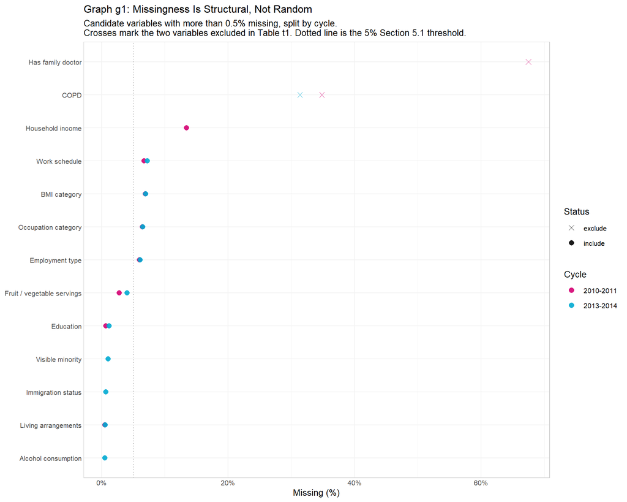

Two points sit far to the right of everything else, and they are far to the right for different reasons.

```
Output out1: Skip-pattern and optional-content evidence
```

```
cc_copd: missing (%) by age group
```

```
 age_group_3     n pct_missing
       15-24  9662       100.0
       25-54 37101        30.9
       55-75 17080         0.2
```

```
Interpretation: the COPD question is administered only to respondents
```

```
aged 35 and over, so absence below that age is by design.
```

```
has_family_doctor: missing (%) by cycle and province
```

```
 province 2010-2011 2013-2014
       NL     100.0       0.1
      PEI     100.0       0.0
       NS     100.0       0.3
       NB     100.0       0.0
       QC     100.0       0.2
       ON       0.1       0.0
       MB     100.0       0.2
       SK     100.0       0.1
       AB     100.0       0.1
       BC     100.0       0.1
       YK     100.0       0.0
```

```
Interpretation: optional content in 2010-2011, selected only by Ontario.
```

```
Retaining it would encode cycle crossed with province, not health access.
```

The COPD question was administered only to respondents aged 35 and over: it is 100% missing below that age and essentially complete above it. A missing indicator for COPD would therefore be a re-labelled age indicator, and `age_group_3` is already a candidate.

The family-doctor question is worse. In 2010–2011 it was optional content that only Ontario selected, so its missingness is an almost exact function of cycle crossed with province — both of which are in the model. Retaining it would let the penalty learn Statistics Canada’s content-selection process.

[output not shown]

The cascade quantifies the price of each choice. Keeping both variables costs roughly two thirds of the sample; dropping both recovers about three quarters of it.

**Review point 2**

Agree or disagree that `cc_copd` and `has_family_doctor` should be excluded rather than imputed or given a missing category. If you disagree, the cascade table tells you what the alternative costs in sample size, and decisions 2 and 3 in Step 4 record how to reverse the choice.

Note the deferred alternative: COPD remains analysable in an age-35-and-over subsample, which is where Section 5.7’s condition-specific model for COPD would have to live in any case.

## Step 3 — The Analytic Sample

```
Output out2: Sample construction arithmetic
```

```
Source rows (Ellis analytic table):         63,843
```

```
Complete cases on included candidates:      48,932
```

```
Dropped:                                    14,911  (23.36%)
```

```
Unit of analysis: one row per CCHS respondent
```

```
Distinct respondent ids:                    48,932
```

```
Duplicate ids:                              0
```

```
Design matrix, perceived health EXCLUDED:   48932  x  88
```

```
Design matrix, perceived health INCLUDED:   48932  x  100
```

Complete-case analysis discards respondents, and discarding is only safe if the discarded resemble the retained. They do not have to match exactly — the model conditions on the variables shown — but a large divergence would signal that the estimates describe a population narrower than intended.

Table t21: Selection-bias check. The complete-case restriction removes 23.4% of respondents; these margins show how far that moves the sample.

| Sample | Mean days absent | Zero days (%) | Female (%) | Age 15-24 (%) | Age 55-75 (%) | Cycle 2013-2014 (%) |
| --- | --- | --- | --- | --- | --- | --- |
| Source (63,843) | 1.351 | 70.5% | 50.6% | 15.1% | 26.8% | 48.9% |
| Analytic (complete case) | 1.391 | 69.3% | 49.6% | 10.3% | 27.1% | 50.9% |

**Review point 3**

Agree or disagree that the analytic sample is close enough to the source population for complete-case analysis to stand. The comparison is descriptive, not a test; a formal treatment would require the multiple imputation Section 5.1 contemplates, which decision 5 defers.

## Step 4 — The Decision Registry

Everything the proposal left open, and how each gap was closed. This table is the spine of the report’s reviewability: it names the alternatives that were available, the one taken, the reason, and whether the choice can be reversed.

Table t3: Decision registry. Every choice made between the Ellis table and the fitted models.

| # | Decision | Alternatives considered | Chosen | Rationale | Reverse by editing |
| --- | --- | --- | --- | --- | --- |
| 1 | Outcome variable | days_absent_total; days_absent_chronic | days_absent_total | Section 5.5 designates it primary, and the 16/9/32/33 reproduction targets derive from it. | `outcome_var` in declare-globals |
| 2 | COPD indicator | Include; exclude; recode as No / Yes / Not asked | Exclude | Asked only of respondents aged 35+, so 100% missing below 35 and 30.9% missing in the 25-54 band. A ‘not asked’ level would be a deterministic function of age, which is already in the model. | `candidate_registry` status for cc_copd |
| 3 | Family doctor indicator | Include; exclude | Exclude | Optional content in 2010-2011, selected only by Ontario: 100% missing in every other province that cycle. Retaining it would make the variable a near-perfect alias for cycle crossed with province. | `candidate_registry` status for has_family_doctor |
| 4 | Age resolution | age_group_3; dhhgage; both | age_group_3 | The two encode the same construct and would compete arbitrarily under the penalty. Section 2.2 specifies the three-category recode. | `candidate_registry` status for dhhgage |
| 5 | Missing data handling | Complete case; explicit Missing level; multiple imputation | Complete case | After decisions 2 and 3 the loss falls from 63.7% to roughly 24%. Section 5.1 permits a separate category only below 5%, which several variables exceed; multiple imputation is deferred rather than dis… | `tweak-data-0` chunk |
| 6 | Perceived health definition | The 3 self-perceived measures; the whole Needs domain | The 3 self-perceived measures | Ratified 2026-07-29. ADL items measure functional limitation, not perception, and injury status is a distinct construct. | `perceived_health_vars` in declare-globals |
| 7 | Dummy coding scheme | Reference (treatment) contrasts; full one-hot | Reference contrasts | Matches the stage-two negative binomial parameterisation. The snippet in Section 5.4 mixes both schemes and is internally inconsistent. | `build_design()` in declare-functions |
| 8 | Cycle indicator | Penalised; unpenalised | Unpenalised (penalty.factor = 0) | The pooled design requires a cycle term whether or not it survives selection. | `forced_vars` in declare-globals |
| 9 | Carry-forward rule to stage 2 | Any surviving column promotes the whole factor; retained levels only | Any surviving column promotes the whole factor | Preserves standard factor contrasts in the negative binomial refit. Level-wise carry-forward would produce non-standard contrasts that are hard to interpret. | `retained_variables()` in declare-functions |
| 10 | Variance estimation | 500 bootstrap replicate weights; Wald standard errors | Wald standard errors | DATA-BLOCKED. Bootstrap replicate weights are absent from the 2010 and 2014 PUMF files; Statistics Canada began releasing them with the 2015 cycle. Documented in CACHE-manifest.md and confirmed with M… | Not reversible without a Research Data Centre file |
| 11 | Penalty selection | 5-fold CV; 10-fold CV; fixed lambda grid | 5-fold CV, seed 42 | Specified in Section 5.4. | `lasso_folds` and `lasso_seed` in declare-globals |
| 12 | Weights in cross-validation | Weighted likelihood; unweighted | Weighted likelihood | Section 5.4 passes survey weights to cv.glmnet. Note that folds are still drawn as though observations were independent; model-0 out4 quantified the consequence. | `weight_vector` in tweak-data-0 |
| 13 | Child-presence flag dhhgl12 | Include in the penalty; exclude from the study; keep for descriptives and bivariate models only | Keep for descriptives and bivariate models only | dhhgl12 is the logical OR of dhhgle5 and dhhg611 in all 63,843 rows, so a design matrix carrying all three spans the same column space as their interaction. A penalty distributes a shared coefficient … | `bivariate_only_vars` in scripts/modeling/candidate-registry.R |
| 14 | Homeownership | Omit; proxy by living_arrangements; include DHH_OWN directly | Include DHH_OWN directly as home_ownership | Section 2.2 requests homeownership. Earlier revisions recorded it as unavailable in the PUMF and used living_arrangements as a proxy; QC on 2026-08-01 showed DHH_OWN is present in both cycles with ide… | `home_ownership` row in scripts/modeling/candidate-registry.R |
| 15 | Interval reporting for Table 3 | Wald only; Wald plus a Huber-White sandwich; Wald plus Kish inflation; all three | All three, side by side | Decision 10 blocks the bootstrap the proposal asks for, so the honest response is to bracket the understatement rather than hide it. The sandwich captures the unequal-weighting component of the design… | `tidy_nb()` and `kish_deff` in declare-globals |
| 16 | Basis for the Section 5.6 cross-validation | Hold the LASSO-selected term set fixed across folds; re-run selection inside each training fold; both | Both, reported side by side | Section 5.6 says ‘repeat model fitting 5 times’, which reads as a fixed term set. That is the compliant number, and it is optimistic, because the penalty already saw every held-out fold. Re-running se… | `cv_performance` in the t63 chunk |
| 17 | C-statistic for a count outcome | Omit; Harrell’s C on predicted mean vs observed count; dichotomise the outcome and use AUC | Harrell’s C on predicted mean vs observed count | Section 5.6 asks for ‘Harrell’s C adapted for count data’. Dichotomising would answer a different question (any absence vs none) and discard the count. Pairs tied on the outcome are not comparable and… | `harrell_c()` in declare-functions |
| 18 | Information criteria under survey weighting | Report AIC/BIC as-is; report with a pseudo-likelihood caveat; omit | Report with a pseudo-likelihood caveat | glm.nb maximises a weighted pseudo-likelihood, so logLik is not a likelihood and AIC’s 2k penalty is not calibrated to it. BIC is worse still: log(n) uses the unweighted row count against a weighted l… | `t61` chunk |
| 19 | Scale of the error metrics | Unweighted RMSE/MAE; weighted RMSE/MAE | Weighted | The models are estimated on a weighted likelihood and the target population is the weighted one, so an unweighted error metric scores a population the analysis is not about. Applies to the in-sample m… | `model_fit_comparison` in the t61 chunk |

**One decision cannot be reversed**

Decision 10 records that bootstrap variance estimation is impossible with these data. CCHS bootstrap replicate weights begin with the 2015 cycle; neither the 2010 nor the 2014 Public Use Microdata File carries them, and strata and PSU identifiers are suppressed as well. Sections 5.3, 5.5, 5.7 and 5.9 all request bootstrap intervals, and none of them can be honoured without the Research Data Centre master files.

**Review point 4**

Read all nineteen decisions. Any one of them can be overturned; the “reversal” column says what to change. This is the table to argue with.

## Step 5 — The Four Specifications

Section 5.4 names four models. They are usually described as four LASSO fits, but they are not: they are two fits read at two penalties each. `cv.glmnet` returns an entire path, and `lambda.min` and `lambda.1se` are two points on it. Recognising this halves the computation and, more usefully, means Models 1 and 3 are guaranteed nested — a comparison that would be merely probable if they came from independent fits.

Table t4: The four specifications of Section 5.4. Models 1 and 3 draw on one cross-validated fit; Models 2 and 4 draw on the other.

| Model | Role | Perceived health | Penalty | Shared CV fit | Candidate variables | Design columns | Target (Sec 5.5) |
| --- | --- | --- | --- | --- | --- | --- | --- |
| Model 1 | Primary | excluded | lambda.1se | exclude | 46 | 88 | 16 |
| Model 2 | Secondary | included | lambda.1se | include | 49 | 100 | 9 |
| Model 3 | Sensitivity | excluded | lambda.min | exclude | 46 | 88 | 32 |
| Model 4 | Sensitivity | included | lambda.min | include | 49 | 100 | 33 |

**Review point 5**

Agree or disagree that “perceived health” means the three self-perceived measures and nothing more. The ADL items and the injury indicator remain in every specification. This scope was ratified on 2026-07-29 and is decision 6.

## Step 6 — Stage One, Penalised Poisson Fitting

**Fit both cross-validated penalised Poisson models and persist them**

```r
lasso_fits <- list(
  exclude = fit_lasso(design_exclude, y_outcome, weight_vector, lasso_seed),
  include = fit_lasso(design_include, y_outcome, weight_vector, lasso_seed)
)

for (fit_name in names(lasso_fits)) {
  saveRDS(lasso_fits[[fit_name]]$cv,
          paste0(fits_folder, "cv_", fit_name, "_perceived.rds"))
  saveRDS(designs[[fit_name]]$map,
          paste0(fits_folder, "map_", fit_name, "_perceived.rds"))
}

cv_curve_data <- purrr::imap_dfr(lasso_fits, function(fit, fit_name) {
  tibble::tibble(
    fit_id = fit_name,
    lambda = fit$cv$lambda,
    cv_mean = fit$cv$cvm,
    cv_low = fit$cv$cvlo,
    cv_high = fit$cv$cvup,
    n_nonzero = fit$cv$nzero
  )
}) %>%
  mutate(fit_label = ifelse(fit_id == "exclude",
                            "Perceived health excluded (Models 1 and 3)",
                            "Perceived health included (Models 2 and 4)"))

lambda_marks <- purrr::imap_dfr(lasso_fits, function(fit, fit_name) {
  tibble::tibble(
    fit_id = fit_name,
    lambda_rule = c("lambda.1se", "lambda.min"),
    lambda = c(fit$cv$lambda.1se, fit$cv$lambda.min)
  )
}) %>%
  mutate(fit_label = ifelse(fit_id == "exclude",
                            "Perceived health excluded (Models 1 and 3)",
                            "Perceived health included (Models 2 and 4)"))

path_data <- purrr::imap_dfr(lasso_fits, function(fit, fit_name) {
  as.matrix(fit$path$beta) %>%
    as.data.frame() %>%
    tibble::rownames_to_column("column") %>%
    tidyr::pivot_longer(-column, names_to = "step", values_to = "estimate") %>%
    mutate(
      lambda = fit$path$lambda[as.integer(sub("^s", "", step)) + 1],
      fit_id = fit_name
    ) %>%
    left_join(designs[[fit_name]]$map, by = "column")
}) %>%
  mutate(
    domain = variable_domains[variable],
    fit_label = ifelse(fit_id == "exclude",
                       "Perceived health excluded (Models 1 and 3)",
                       "Perceived health included (Models 2 and 4)")
  )
```

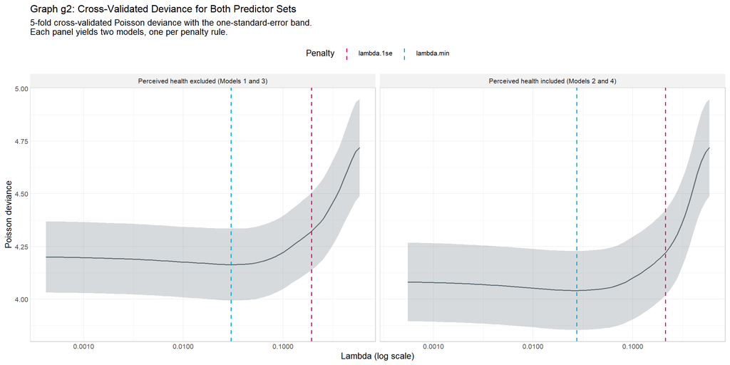

Both curves are shallow to the left of their minima. That flatness is what makes the one-standard-error rule bite: over a wide range of penalties, cross-validation genuinely cannot tell the models apart, so `lambda.1se` sits far from `lambda.min` and discards a great deal at almost no measurable cost in deviance.

[figure not shown]

Reading right to left, the order in which coefficients leave zero is the order in which the data insist on them. In both panels the last survivors are drawn from the Needs and Exposure domains; the Facilitating domain collapses early.

**Review point 6**

Agree or disagree with the fitting choices visible here: five folds, seed 42, survey weights passed to `cv.glmnet`, and the cycle indicator exempted from the penalty. Decisions 8, 11 and 12 cover these.

## Step 7 — Selection Results

Table t5: Selection counts against the reproduction targets of Section 5.5. The ‘variables’ count promotes a factor whenever any of its columns survived.

| Model | Role | Perceived health | Penalty | Columns offered | Columns retained | Variables retained | Target (Sec 5.5) | Gap |
| --- | --- | --- | --- | --- | --- | --- | --- | --- |
| Model 1 | Primary | excluded | lambda.1se | 88 | 10 | 10 | 16 | -6 |
| Model 2 | Secondary | included | lambda.1se | 100 | 12 | 9 | 9 | +0 |
| Model 3 | Sensitivity | excluded | lambda.min | 88 | 46 | 38 | 32 | +6 |
| Model 4 | Sensitivity | included | lambda.min | 100 | 57 | 42 | 33 | +9 |

Table t51: Which variables each specification retained

| Domain | Variable | Model 1 | Model 2 | Model 3 | Model 4 |
| --- | --- | --- | --- | --- | --- |
| Exposure | Anxiety disorder |  |  | kept | kept |
| Exposure | Arthritis | kept |  | kept | kept |
| Exposure | Asthma |  |  | kept | kept |
| Exposure | Back problems | kept | kept | kept | kept |
| Exposure | Bowel disorder | kept |  | kept | kept |
| Exposure | Cancer |  |  | kept | kept |
| Exposure | Chronic fatigue syndrome | kept |  | kept | kept |
| Exposure | Diabetes |  |  | kept | kept |
| Exposure | Fibromyalgia |  |  | kept | kept |
| Exposure | Heart disease |  |  | kept | kept |
| Exposure | Hypertension |  |  | kept | kept |
| Exposure | Migraine | kept | kept | kept | kept |
| Exposure | Mood disorder | kept | kept | kept | kept |
| Exposure | Multiple chemical sensitivities |  |  | kept | kept |
| Exposure | Stomach / intestinal ulcer |  |  | kept | kept |
| Exposure | Stroke |  |  |  |  |
| Predisposing | Age group |  |  | kept | kept |
| Predisposing | Child aged 0-5 in household |  |  |  |  |
| Predisposing | Child aged 6-11 in household |  |  | kept | kept |
| Predisposing | Education |  |  |  |  |
| Predisposing | Home ownership |  |  | kept | kept |
| Predisposing | Household size |  |  |  |  |
| Predisposing | Immigration status |  |  | kept | kept |
| Predisposing | Living arrangements |  |  | kept | kept |
| Predisposing | Marital status |  |  | kept | kept |
| Predisposing | Sex |  |  | kept | kept |
| Predisposing | Visible minority |  |  |  | kept |
| Facilitating | Alcohol consumption |  |  | kept | kept |
| Facilitating | BMI category |  |  | kept | kept |
| Facilitating | Employment type |  |  | kept | kept |
| Facilitating | Fruit / vegetable servings |  |  | kept | kept |
| Facilitating | Household income |  |  |  |  |
| Facilitating | Occupation category |  |  |  | kept |
| Facilitating | Physical activity |  |  | kept | kept |
| Facilitating | Province |  |  | kept | kept |
| Facilitating | Smoking status |  |  | kept |  |
| Facilitating | Work schedule |  |  | kept | kept |
| Facilitating | Work stress |  |  | kept | kept |
| Needs | Health vs prior year |  | kept |  | kept |
| Needs | Injured in past 12 months | kept | kept | kept | kept |
| Needs | Needs help: errands | kept | kept | kept | kept |
| Needs | Needs help: finances |  |  | kept | kept |
| Needs | Needs help: housework | kept | kept | kept | kept |
| Needs | Needs help: meals |  |  | kept | kept |
| Needs | Needs help: moving indoors |  |  |  |  |
| Needs | Needs help: personal care |  |  | kept | kept |
| Needs | Self-perceived general health |  | kept |  | kept |
| Needs | Self-perceived mental health |  |  |  | kept |
| Survey design | CCHS cycle | kept | kept | kept | kept |

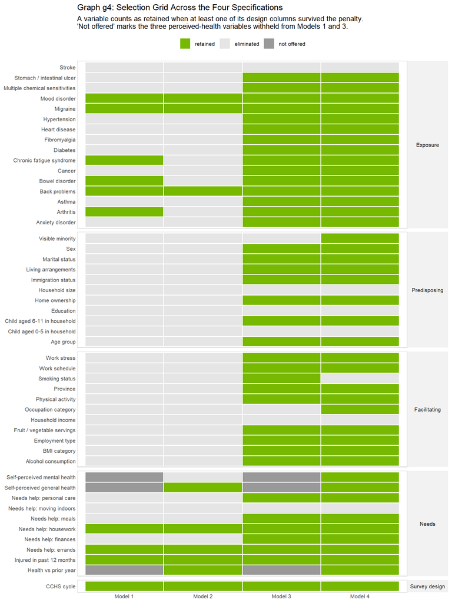

Graph g4 is the report’s central artifact and repays slow reading. Scanning down a column shows one specification’s whole verdict; scanning across a row shows how stable a variable’s selection is to the penalty rule and the predictor set. Variables retained in all four columns are robust. Variables appearing only in Models 3 and 4 are artifacts of a permissive penalty.

**Review point 7**

This is the report’s substantive output. Two questions to settle:

1. Is the divergence from the proposal’s anticipated counts acceptable, or does it indicate that a different lambda rule, coding scheme, or candidate set was assumed when those numbers were written?
2. Should “retained” continue to mean “at least one design column survived”? Decision 9 records the alternative — carrying only the surviving levels into stage two — which would produce smaller but harder-to-interpret models.

## Step 8 — Stage Two, Negative Binomial Estimation

Each retained set is now re-estimated without penalty under a negative binomial likelihood, as Section 5.4 stage two directs. The penalty’s job was selection; it biases coefficients toward zero and must not be carried into estimation.

This step is where Section 5.5 is answered and where deliverable **Table 3** is produced. Before the estimates, the instruments used to bracket their uncertainty.

**Fit and persist the four negative binomial models and the null**

```r
nb_fits <- purrr::map(
  stats::setNames(model_specs$spec_id, model_specs$spec_id),
  function(this_spec) {
    spec_row <- model_specs %>% filter(spec_id == this_spec)
    kept <- selection_long %>%
      filter(spec_id == this_spec) %>%
      retained_variables()
    term_vars <- union(forced_vars, setdiff(kept, forced_vars))
    fit_nb(ds1, term_vars, outcome_var)
  }
)

nb_null <- fit_nb(ds1, character(0), outcome_var)

for (this_spec in names(nb_fits)) {
  saveRDS(nb_fits[[this_spec]], paste0(fits_folder, "nb_", this_spec, ".rds"))
}
saveRDS(nb_null, paste0(fits_folder, "nb_null.rds"))

nb_coefficients <- purrr::imap_dfr(nb_fits, function(fit, this_spec) {
  fit_id <- model_specs$fit_id[model_specs$spec_id == this_spec]
  tidy_nb(fit, designs[[fit_id]]$map, deff = kish_deff) %>%
    mutate(spec_id = this_spec,
           model_label = model_specs$model_label[model_specs$spec_id == this_spec])
}) %>%
  mutate(domain = variable_domains[variable],
         variable_label = variable_labels[variable])

readr::write_csv(nb_coefficients, paste0(local_data, "nb-coefficients.csv"))
```

```
Output out5: Variance-estimation instruments for Section 5.5
```

```
The proposal asks for 500 bootstrap replicate weights. They do not exist in
```

```
the 2010 or 2014 PUMF (decision 10), and strata and PSU identifiers are
```

```
suppressed, so no fully design-based variance estimator can be built. What
```

```
follows are two LOWER bounds on how much the model-based intervals
```

```
understate uncertainty. Neither instrument can see clustering, so the true
```

```
inflation is larger than both.
```

```
  analytic n:              48,932
```

```
  Kish design effect:      3.637
```

```
  Kish effective n:       13,452 of 48,932
```

```
  implied SE multiplier:   1.907   (square root of the design effect)
```

```
  sandwich SE multiplier:  1.985   (median over every term in all four models)
```

```
  sandwich range:         0.585 to 4.208
```

```
Table t62 reports all three interval variants side by side. A term whose
```

```
Wald interval excludes 1 but whose Kish-inflated interval does not should
```

```
be read as unresolved rather than as a finding.
```

The two multipliers disagree, and the disagreement is informative. Kish’s is a single number applied to every term; the sandwich is estimated per term and so reflects which coefficients are actually sensitive to the weighting. Neither sees clustering. A reader who wants a single rule of thumb should take the larger of the two and treat it as still too small.

Table t6 (deliverable Table 3): Adjusted prevalence rate ratios with 95% Wald intervals across the four Section 5.4 specifications. An asterisk marks Wald p < 0.05. These are NOT bootstrap intervals (decision 10), and they ignore the selection step that produced the term list. Table t62 carries the log-scale coefficients, standard errors, exact p-values, and two wider interval variants.

| Domain | Term | Model 1 | Model 2 | Model 3 | Model 4 |
| --- | --- | --- | --- | --- | --- |
| Exposure | Anxiety disorder: Yes |  |  | 1.206 (1.086-1.339)* | 1.101 (0.992-1.222) |
| Exposure | Arthritis: Yes | 1.411 (1.309-1.521)* |  | 1.335 (1.236-1.442)* | 1.221 (1.131-1.318)* |
| Exposure | Asthma: Yes |  |  | 1.185 (1.090-1.288)* | 1.155 (1.064-1.254)* |
| Exposure | Back problems: Yes | 1.436 (1.351-1.527)* | 1.389 (1.309-1.474)* | 1.426 (1.342-1.515)* | 1.354 (1.275-1.437)* |
| Exposure | Bowel disorder: Yes | 1.646 (1.472-1.841)* |  | 1.585 (1.419-1.770)* | 1.362 (1.222-1.519)* |
| Exposure | Cancer: Yes |  |  | 2.748 (2.191-3.448)* | 2.063 (1.650-2.580)* |
| Exposure | Chronic fatigue syndrome: Yes | 1.582 (1.226-2.041)* |  | 1.202 (0.932-1.552) | 1.022 (0.795-1.313) |
| Exposure | Diabetes: Yes |  |  | 1.229 (1.094-1.382)* | 1.107 (0.985-1.244) |
| Exposure | Fibromyalgia: Yes |  |  | 0.822 (0.663-1.020) | 0.793 (0.641-0.980)* |
| Exposure | Heart disease: Yes |  |  | 2.049 (1.761-2.383)* | 1.551 (1.334-1.803)* |
| Exposure | Hypertension: Yes |  |  | 1.066 (0.990-1.149) | 0.962 (0.893-1.036) |
| Exposure | Migraine: Yes | 1.625 (1.509-1.750)* | 1.602 (1.490-1.722)* | 1.407 (1.307-1.515)* | 1.388 (1.290-1.493)* |
| Exposure | Mood disorder: Yes | 2.120 (1.931-2.328)* | 1.835 (1.674-2.012)* | 1.764 (1.601-1.944)* | 1.523 (1.378-1.683)* |
| Exposure | Multiple chemical sensitivities: Yes |  |  | 1.088 (0.935-1.267) | 1.102 (0.950-1.280) |
| Exposure | Stomach / intestinal ulcer: Yes |  |  | 1.675 (1.450-1.936)* | 1.293 (1.121-1.492)* |
| Predisposing | Age group: 25-54 |  |  | 1.169 (1.067-1.281)* | 1.197 (1.094-1.310)* |
| Predisposing | Age group: 55-75 |  |  | 1.011 (0.905-1.130) | 1.025 (0.919-1.143) |
| Predisposing | Child aged 6-11 in household: Yes |  |  | 0.903 (0.843-0.967)* | 0.878 (0.820-0.939)* |
| Predisposing | Home ownership: Renter |  |  | 1.097 (1.034-1.163)* | 1.096 (1.035-1.161)* |
| Predisposing | Immigration status: Long-term immigrant (10+ yrs in Canada) |  |  | 0.842 (0.789-0.899)* | 0.840 (0.781-0.904)* |
| Predisposing | Immigration status: Recent immigrant (0-9 yrs in Canada) |  |  | 0.829 (0.751-0.916)* | 0.812 (0.730-0.904)* |
| Predisposing | Living arrangements: Child in parent / sibling household |  |  | 1.288 (1.097-1.513)* | 1.264 (1.078-1.481)* |
| Predisposing | Living arrangements: Child in two-parent / sibling household |  |  | 1.061 (0.938-1.200) | 1.106 (0.979-1.248) |
| Predisposing | Living arrangements: Couple with children |  |  | 0.993 (0.854-1.154) | 0.966 (0.833-1.121) |
| Predisposing | Living arrangements: Couple, no children |  |  | 1.025 (0.882-1.191) | 0.996 (0.858-1.155) |
| Predisposing | Living arrangements: Other arrangement |  |  | 0.977 (0.850-1.124) | 0.946 (0.823-1.086) |
| Predisposing | Living arrangements: Single parent with child |  |  | 1.004 (0.885-1.138) | 1.030 (0.910-1.166) |
| Predisposing | Living arrangements: Unattached, living with others |  |  | 1.182 (1.055-1.325)* | 1.212 (1.084-1.356)* |
| Predisposing | Marital status: Common-law |  |  | 0.936 (0.871-1.007) | 0.928 (0.864-0.996)* |
| Predisposing | Marital status: Single / Never married |  |  | 1.189 (1.032-1.371)* | 1.147 (0.997-1.319) |

[output cut: 54 more lines]

Table t62 (deliverable Table 3, full ledger): Everything Section 5.5 asks to be reported - log-scale coefficient, standard error, prevalence rate ratio, 95% interval and Wald p-value - for every term in all four models. The sandwich and Kish columns bracket the understatement caused by the absent bootstrap weights (decisions 10 and 15); both are lower bounds. All intervals remain conditional on a selection step that used the same data.

| Model | Domain | Term | Beta (log) | SE | SE robust | PR | 95% CI (Wald) | 95% CI (sandwich) | 95% CI (Kish) | p (Wald) | p (robust) |
| --- | --- | --- | --- | --- | --- | --- | --- | --- | --- | --- | --- |
| Model 1 | Exposure | Arthritis: Yes | 0.3445 | 0.0382 | 0.0612 | 1.411 | 1.309-1.521 | 1.252-1.591 | 1.223-1.628 | <0.0001 | <0.0001 |
| Model 1 | Exposure | Back problems: Yes | 0.3621 | 0.0311 | 0.0569 | 1.436 | 1.351-1.527 | 1.285-1.606 | 1.279-1.613 | <0.0001 | <0.0001 |
| Model 1 | Exposure | Bowel disorder: Yes | 0.4985 | 0.0570 | 0.1268 | 1.646 | 1.472-1.841 | 1.284-2.111 | 1.330-2.037 | <0.0001 | <0.0001 |
| Model 1 | Exposure | Chronic fatigue syndrome: Yes | 0.4588 | 0.1299 | 0.1568 | 1.582 | 1.226-2.041 | 1.163-2.152 | 0.973-2.572 | 0.0004 | 0.0034 |
| Model 1 | Exposure | Migraine: Yes | 0.4856 | 0.0378 | 0.0781 | 1.625 | 1.509-1.750 | 1.394-1.894 | 1.411-1.872 | <0.0001 | <0.0001 |
| Model 1 | Exposure | Mood disorder: Yes | 0.7515 | 0.0477 | 0.0662 | 2.120 | 1.931-2.328 | 1.862-2.414 | 1.774-2.534 | <0.0001 | <0.0001 |
| Model 1 | Needs | Injured in past 12 months: Yes | 0.6458 | 0.0306 | 0.0518 | 1.907 | 1.796-2.025 | 1.723-2.111 | 1.701-2.139 | <0.0001 | <0.0001 |
| Model 1 | Needs | Needs help: errands: Yes | 0.9087 | 0.1066 | 0.1426 | 2.481 | 2.013-3.058 | 1.876-3.281 | 1.666-3.696 | <0.0001 | <0.0001 |
| Model 1 | Needs | Needs help: housework: Yes | 0.5988 | 0.0838 | 0.1159 | 1.820 | 1.544-2.145 | 1.450-2.284 | 1.331-2.490 | <0.0001 | <0.0001 |
| Model 1 | Survey design | CCHS cycle: 2013-2014 | 0.1511 | 0.0231 | 0.0605 | 1.163 | 1.112-1.217 | 1.033-1.309 | 1.067-1.268 | <0.0001 | 0.0125 |
| Model 2 | Exposure | Back problems: Yes | 0.3287 | 0.0302 | 0.0584 | 1.389 | 1.309-1.474 | 1.239-1.558 | 1.241-1.555 | <0.0001 | <0.0001 |
| Model 2 | Exposure | Migraine: Yes | 0.4712 | 0.0369 | 0.0739 | 1.602 | 1.490-1.722 | 1.386-1.852 | 1.395-1.839 | <0.0001 | <0.0001 |
| Model 2 | Exposure | Mood disorder: Yes | 0.6072 | 0.0468 | 0.0670 | 1.835 | 1.674-2.012 | 1.610-2.093 | 1.541-2.186 | <0.0001 | <0.0001 |
| Model 2 | Needs | Health vs prior year: About the same | -0.3434 | 0.0416 | 0.1091 | 0.709 | 0.654-0.770 | 0.573-0.879 | 0.607-0.829 | <0.0001 | 0.0017 |
| Model 2 | Needs | Health vs prior year: Much worse | 0.7901 | 0.1446 | 0.1897 | 2.204 | 1.660-2.926 | 1.519-3.196 | 1.284-3.783 | <0.0001 | <0.0001 |
| Model 2 | Needs | Health vs prior year: Somewhat better | -0.1662 | 0.0504 | 0.1158 | 0.847 | 0.767-0.935 | 0.675-1.063 | 0.701-1.022 | 0.0010 | 0.1511 |
| Model 2 | Needs | Health vs prior year: Somewhat worse | 0.3154 | 0.0549 | 0.1249 | 1.371 | 1.231-1.527 | 1.073-1.751 | 1.116-1.683 | <0.0001 | 0.0116 |
| Model 2 | Needs | Injured in past 12 months: Yes | 0.6609 | 0.0300 | 0.0539 | 1.937 | 1.826-2.054 | 1.743-2.152 | 1.731-2.167 | <0.0001 | <0.0001 |
| Model 2 | Needs | Needs help: errands: Yes | 0.7212 | 0.1045 | 0.1655 | 2.057 | 1.676-2.524 | 1.487-2.845 | 1.392-3.040 | <0.0001 | <0.0001 |
| Model 2 | Needs | Needs help: housework: Yes | 0.4212 | 0.0819 | 0.1251 | 1.524 | 1.298-1.789 | 1.193-1.947 | 1.122-2.069 | <0.0001 | 0.0008 |
| Model 2 | Needs | Self-perceived general health: Fair | 0.9372 | 0.0542 | 0.0991 | 2.553 | 2.295-2.839 | 2.102-3.100 | 2.084-3.126 | <0.0001 | <0.0001 |
| Model 2 | Needs | Self-perceived general health: Good | 0.5549 | 0.0329 | 0.0653 | 1.742 | 1.633-1.858 | 1.532-1.980 | 1.540-1.970 | <0.0001 | <0.0001 |
| Model 2 | Needs | Self-perceived general health: Poor | 1.2485 | 0.1251 | 0.1714 | 3.485 | 2.727-4.454 | 2.491-4.876 | 2.183-5.564 | <0.0001 | <0.0001 |
| Model 2 | Needs | Self-perceived general health: Very good | 0.3860 | 0.0298 | 0.0807 | 1.471 | 1.388-1.560 | 1.256-1.723 | 1.316-1.645 | <0.0001 | <0.0001 |
| Model 2 | Survey design | CCHS cycle: 2013-2014 | 0.1611 | 0.0228 | 0.0593 | 1.175 | 1.124-1.228 | 1.046-1.320 | 1.079-1.279 | <0.0001 | 0.0065 |
| Model 3 | Exposure | Anxiety disorder: Yes | 0.1871 | 0.0536 | 0.0752 | 1.206 | 1.086-1.339 | 1.041-1.397 | 0.987-1.473 | 0.0005 | 0.0128 |
| Model 3 | Exposure | Arthritis: Yes | 0.2887 | 0.0394 | 0.0700 | 1.335 | 1.236-1.442 | 1.164-1.531 | 1.152-1.546 | <0.0001 | <0.0001 |
| Model 3 | Exposure | Asthma: Yes | 0.1696 | 0.0426 | 0.0675 | 1.185 | 1.090-1.288 | 1.038-1.353 | 1.011-1.389 | <0.0001 | 0.0121 |
| Model 3 | Exposure | Back problems: Yes | 0.3550 | 0.0309 | 0.0604 | 1.426 | 1.342-1.515 | 1.267-1.605 | 1.271-1.601 | <0.0001 | <0.0001 |
| Model 3 | Exposure | Bowel disorder: Yes | 0.4605 | 0.0564 | 0.1586 | 1.585 | 1.419-1.770 | 1.161-2.163 | 1.283-1.957 | <0.0001 | 0.0037 |

[output cut: 143 more lines]

Table t62 is the compliance artifact: every quantity Section 5.5 names, for every term, in all four models. Read the three interval columns together. Where the Wald and Kish intervals agree about whether they contain 1, the conclusion survives the weighting problem. Where they disagree, it does not, and the term should be described as unresolved rather than null or significant.

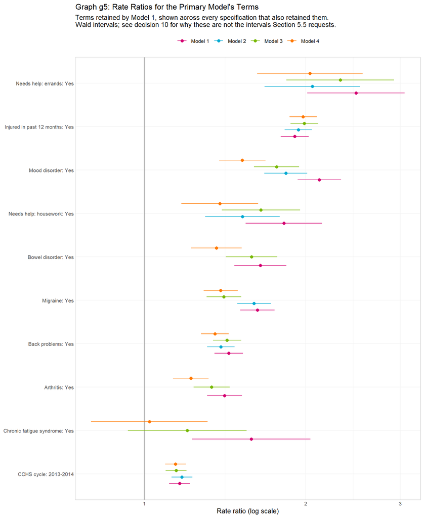

Table t61: Section 5.6 metrics computed IN SAMPLE. RMSE and MAE are weighted (decision 19). AIC and BIC come from a weighted pseudo-likelihood and rank models rather than measure them (decision 18); BIC in particular sets log(n) on the unweighted row count against a weighted likelihood. The C-statistic excludes pairs tied on the outcome, which here is most pairs - see out6. The held-out versions of these numbers, which are the ones Section 5.6 actually asks for, are in Tables t63 and t64.

| Model | Role | n | Weighted N | Terms | AIC | BIC | McFadden R2 | Theta | RMSE | MAE | C-statistic | Converged |
| --- | --- | --- | --- | --- | --- | --- | --- | --- | --- | --- | --- | --- |
| Model 1 | Primary | 48,932 | 14,096,545 | 10 | 121,536 | 121,642 | 0.0200 | 0.1824 | 4.020 | 1.785 | 0.6131 | yes |
| Model 2 | Secondary | 48,932 | 14,096,545 | 15 | 120,557 | 120,707 | 0.0280 | 0.1931 | 3.968 | 1.752 | 0.6318 | yes |
| Model 3 | Sensitivity | 48,932 | 14,096,545 | 67 | 120,593 | 121,200 | 0.0285 | 0.1934 | 4.197 | 1.775 | 0.6520 | yes |
| Model 4 | Sensitivity | 48,932 | 14,096,545 | 81 | 119,715 | 120,445 | 0.0358 | 0.2039 | 4.352 | 1.753 | 0.6647 | yes |

```
Output out3: Convergence, dispersion, and the null-model comparison
```

```
Stage 1 - penalised Poisson fits
```

```
Perceived health EXCLUDED
  columns offered:   88
  lambda.min:        0.030123   ->  46  columns
  lambda.1se:        0.193633   ->  10  columns
  CV deviance at min: 4.1641   SE band width: 0.1704

Perceived health INCLUDED
  columns offered:   100
  lambda.min:        0.027485   ->  57  columns
  lambda.1se:        0.212805   ->  12  columns
  CV deviance at min: 4.0411   SE band width: 0.1876
```

```
Stage 2 - negative binomial refits
```

```
Model 1
  converged:         TRUE  in  1  iterations
  theta:             0.1824  (SE  0.0021 )
  terms estimated:   10

Model 2
  converged:         TRUE  in  1  iterations
  theta:             0.1931  (SE  0.0023 )
  terms estimated:   15

Model 3
  converged:         TRUE  in  1  iterations
  theta:             0.1934  (SE  0.0023 )
  terms estimated:   67

Model 4
  converged:         TRUE  in  1  iterations
  theta:             0.2039  (SE  0.0024 )
  terms estimated:   81
```

Four cautions about the comparison table. The pseudo-$R^2$ values are small in absolute terms, which is unremarkable for individual-level count outcomes and should not be read as failure. AIC and BIC both favour the permissive specifications, which is what one expects when they are supersets — but both are computed from a *weighted pseudo-likelihood*, so they rank models rather than measure them, and BIC’s $\log(n)$ penalty sets an unweighted row count against a weighted likelihood (decision 18). The root-mean-square error moves in the *opposite* direction to the likelihood — richer models fit worse on the raw day scale — because a squared-error criterion on a heavily zero-inflated count is dominated by a handful of extreme observations, which the richer models chase. And every number in t61 is in-sample; Section 5.6 asks for the held-out versions, which arrive in Step 9.

**Review point 8**

Agree or disagree that the estimates in Tables t6 and t62 are fit to serve as the study’s Table 3: all models converged, dispersion is estimated well away from the Poisson limit, and rate ratios move in plausible directions and magnitudes. The specific question to settle is decision 15 — whether reporting three interval variants is the right response to the missing bootstrap, or whether one of them should be designated the interval of record.

## Step 9 — Section 5.6, Held-Out Performance

Section 5.6 asks for AIC, BIC, McFadden’s pseudo-$R^2$, a C-statistic, and RMSE and MAE “computed on the withheld test fold,” averaged over five folds. Table t61 gave the in-sample versions of the first three. This step supplies the rest.

A clarification first, because the two cross-validations in this report are easily confused. The folds in Step 6 belong to `cv.glmnet`: they tune the *penalty* on a Poisson deviance and are internal to selection. The folds here are a separate, explicitly seeded partition used to estimate *prediction error* for the negative binomial refits. They are both five-fold because both sections say five. They are not the same folds and they do not answer the same question.

**Five-fold cross-validation of all four specifications, both variants**

```r
if (!force_refit_cv && file.exists(cv_cache_path)) {
  cv_performance <- readRDS(cv_cache_path)
  cat("Loaded cached cross-validation results from ", cv_cache_path, "\n", sep = "")
} else {
  cat("Refitting the Section 5.6 cross-validation. This is the slow block.\n")
  cv_start_time <- Sys.time()

  fold_id <- assign_folds(n_analytic, perf_folds, perf_seed)
  spec_terms_fixed <- purrr::map(
    stats::setNames(model_specs$spec_id, model_specs$spec_id),
    function(this_spec) {
      kept <- selection_long %>% filter(spec_id == this_spec) %>% retained_variables()
      union(forced_vars, setdiff(kept, forced_vars))
    }
  )

  # Variant A - fixed term set.
  cv_fixed <- purrr::map_dfr(seq_len(perf_folds), function(this_fold) {
    test_rows <- which(fold_id == this_fold)
    train_rows <- which(fold_id != this_fold)
    cat("  fixed  | fold ", this_fold, " of ", perf_folds, "\n", sep = "")
    purrr::imap_dfr(spec_terms_fixed, function(term_vars, this_spec) {
      evaluate_fold(ds1, train_rows, test_rows, term_vars, outcome_var) %>%
        mutate(spec_id = this_spec, fold = this_fold, variant = "fixed term set")
    })
  })

  # Variant B - selection re-run inside each training fold.
  cv_reselected <- purrr::map_dfr(seq_len(perf_folds), function(this_fold) {
    test_rows <- which(fold_id == this_fold)
    train_rows <- which(fold_id != this_fold)
    cat("  reselect | fold ", this_fold, " of ", perf_folds, "\n", sep = "")

    train_frame <- droplevels(ds1[train_rows, , drop = FALSE])
    fold_designs <- list(
      exclude = build_design(train_frame, c(forced_vars, vars_excluding_perceived)),
      include = build_design(train_frame, c(forced_vars, vars_including_perceived))
    )
    fold_lassos <- purrr::map(
      fold_designs,
      ~ fit_lasso(.x, train_frame[[outcome_var]], train_frame$weight_scaled, lasso_seed)
    )

    purrr::pmap_dfr(
      model_specs %>% select(spec_id, fit_id, lambda_rule),
      function(spec_id, fit_id, lambda_rule) {
        kept <- coefficients_at(fold_lassos[[fit_id]], fold_designs[[fit_id]],
                                lambda_rule) %>%
          retained_variables()
        term_vars <- union(forced_vars, setdiff(kept, forced_vars))
        evaluate_fold(ds1, train_rows, test_rows, term_vars, outcome_var) %>%
          mutate(spec_id = spec_id, fold = this_fold,
                 variant = "selection re-run", n_vars_selected = length(term_vars))
      }
    )
  })

  cv_performance <- bind_rows(cv_fixed, cv_reselected) %>%
    left_join(model_specs %>% select(spec_id, model_label, role), by = "spec_id")

  attr(cv_performance, "elapsed_minutes") <-
    as.numeric(difftime(Sys.time(), cv_start_time, units = "mins"))
  attr(cv_performance, "fold_id") <- fold_id
  saveRDS(cv_performance, cv_cache_path)
}

readr::write_csv(cv_performance, paste0(local_data, "cv-performance-folds.csv"))

cv_summary <- cv_performance %>%
  group_by(variant, spec_id, model_label, role) %>%
  summarise(
    n_terms_mean = mean(n_terms),
    n_terms_range = paste0(min(n_terms), "-", max(n_terms)),
    rmse_mean = mean(rmse), rmse_sd = stats::sd(rmse),
    mae_mean = mean(mae), mae_sd = stats::sd(mae),
    mcfadden_mean = mean(mcfadden_r2), mcfadden_sd = stats::sd(mcfadden_r2),
    c_mean = mean(c_statistic), c_sd = stats::sd(c_statistic),
    comparable_share = mean(comparable_share),
    unscorable = sum(n_unscorable),
    all_converged = all(converged),
    .groups = "drop"
  ) %>%
  arrange(variant, spec_id)

readr::write_csv(cv_summary, paste0(local_data, "cv-performance-summary.csv"))
```

Table t63: Section 5.6 five-fold cross-validated performance, term set held FIXED across folds. Each cell is the mean over five folds with the between-fold standard deviation in parentheses. Metrics are computed on the withheld fold only, weighted (decision 19). These numbers are optimistic: the LASSO that chose the term set saw every fold (decision 16). Table t64 removes that advantage.

| Model | Role | Terms | CV RMSE | CV MAE | CV McFadden R2 | CV C-statistic | Comparable pairs | Converged |
| --- | --- | --- | --- | --- | --- | --- | --- | --- |
| Model 1 | Primary | 10 | 4.021 (0.304) | 1.786 (0.084) | 0.0193 (0.0026) | 0.6131 (0.0077) | 49.1% | all folds |
| Model 2 | Secondary | 15 | 3.978 (0.356) | 1.756 (0.086) | 0.0266 (0.0026) | 0.6302 (0.0071) | 49.1% | all folds |
| Model 3 | Sensitivity | 67 | 4.228 (0.416) | 1.787 (0.088) | 0.0205 (0.0058) | 0.6397 (0.0093) | 49.1% | all folds |
| Model 4 | Sensitivity | 81 | 4.460 (0.480) | 1.774 (0.085) | 0.0266 (0.0064) | 0.6529 (0.0093) | 49.1% | all folds |

Table t63 is the literal answer to Section 5.6: the term set is what the full-sample LASSO chose, and the negative binomial is refitted five times with a fifth of the sample withheld each time. It is also, for that reason, optimistic. The penalty that produced the term list saw every respondent, including the ones being predicted.

Table t64: The same five folds, with the entire LASSO re-run inside each training fold so that no held-out respondent contributed to selection. The term range shows how much the selected set moves when a fifth of the sample is withheld - a direct measure of selection stability that the single full-sample fit cannot provide.

| Model | Role | Terms (mean) | Terms (range) | CV RMSE | CV MAE | CV McFadden R2 | CV C-statistic | Converged |
| --- | --- | --- | --- | --- | --- | --- | --- | --- |
| Model 1 | Primary | 15 | 8-38 | 4.010 (0.355) | 1.783 (0.083) | 0.0192 (0.0036) | 0.6162 (0.0217) | all folds |
| Model 2 | Secondary | 20 | 15-31 | 4.039 (0.357) | 1.761 (0.081) | 0.0271 (0.0028) | 0.6349 (0.0178) | all folds |
| Model 3 | Sensitivity | 74 | 68-83 | 4.241 (0.385) | 1.789 (0.083) | 0.0188 (0.0060) | 0.6370 (0.0088) | all folds |
| Model 4 | Sensitivity | 85 | 81-91 | 4.537 (0.467) | 1.780 (0.079) | 0.0248 (0.0069) | 0.6512 (0.0096) | all folds |

Table t64 removes that advantage by re-running the entire two-stage procedure inside each training fold, so no held-out respondent contributed to selection. The term-count range is worth as much as the metrics: it says how far the selected set moves when a fifth of the sample is taken away, which no single full-sample fit can reveal.

Two results deserve to be read together, because they point in opposite directions.

The **selected set** moves a great deal. Model 1 retains ten variables on the full sample; across the five training folds it retains between eight and thirty-eight. The parsimonious specification is therefore not a stable object. It predicts about as well as any other fold’s version, but *which* variables it names is substantially a function of which four-fifths of the sample it saw. Any narrative built on the identity of the Model 1 variable list — rather than on the estimates attached to it — needs to reckon with that range.

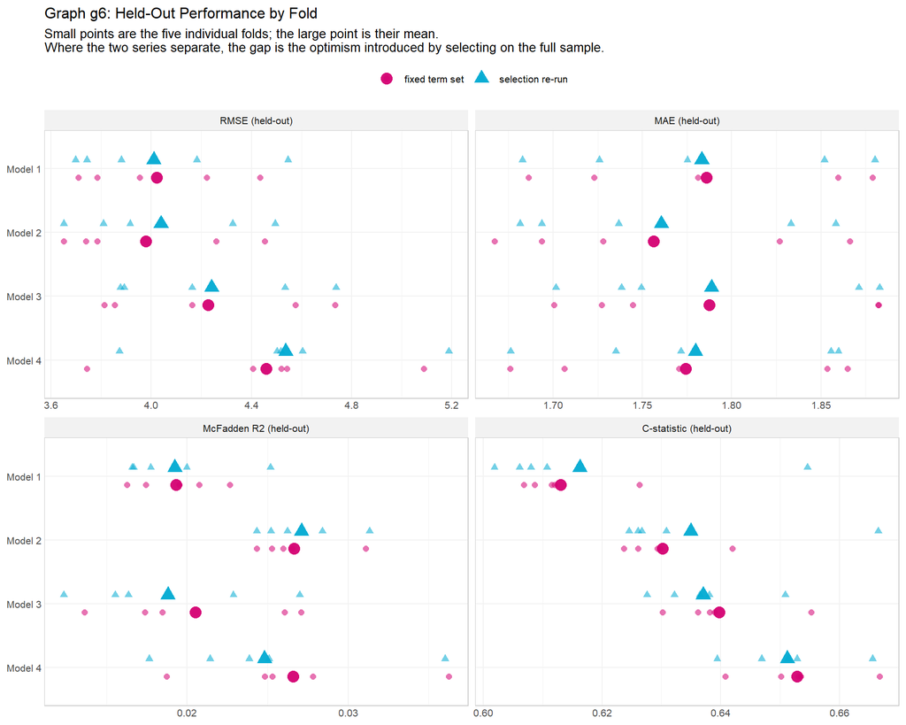

Graph g6 shows the five folds individually rather than only their mean. Between- fold spread is the honest error bar on a cross-validated metric, and a difference between two models that is smaller than the spread within either of them is not a difference.

```
Output out6: How to read the C-statistic on a count outcome
```

```
  share of respondents at zero days: 69.3%
```

```
  comparable pair share (fixed):     49.1%
```

```
Harrell's C counts a pair only when the two respondents differ on the
```

```
outcome. Because most respondents share the value zero, most pairs are not
```

```
comparable and never enter the denominator. The statistic therefore
```

```
measures how well the model orders respondents who differ in days absent,
```

```
and says nothing about how well it separates any-absence from none. That
```

```
second question is a different one and is not what Section 5.6 asked for.
```

```
Selection optimism (fixed minus re-run), per model:
```

```
   Model  d RMSE d McFadden     d C
 Model 1 +0.0108    +0.0001 -0.0032
 Model 2 -0.0610    -0.0005 -0.0048
 Model 3 -0.0129    +0.0017 +0.0027
 Model 4 -0.0772    +0.0018 +0.0017
```

```
A positive d McFadden or d C is the amount by which evaluating a model on
```

```
data that helped select it flatters that model.
```

```
  cross-validation runtime: 2.9 minutes
```

**The C-statistic here is a narrow instrument**

Harrell’s C counts only pairs of respondents who differ on the outcome. Seven in ten respondents report zero days absent, so only about half of all pairs are comparable and the rest never enter the denominator. The reported C therefore measures how well the model *orders respondents who differ in days absent*. It says nothing about how well the model separates any absence from none — a question this outcome makes tempting to ask, but not one Section 5.6 asked, and not one a rate-ratio model is built to answer.

**Review point 9**

Three questions.

1. Which table is the Section 5.6 deliverable — t63, which follows the proposal’s wording, or t64, which is what the numbers would be on new data? Decision 16 reports both rather than choosing; a reader may reasonably insist on a choice. Given how small the gap turns out to be, either answer is defensible.
2. Does the term-count range in t64 change how Model 1’s variable list should be described in the manuscript? “The variables LASSO selected” and “the variables LASSO would select from a comparable sample” are not the same claim, and t64 says the second is much looser than the first.
3. Is the C-statistic worth reporting at all given the comparable-pair share in out6, or should it be accompanied by a discrimination measure suited to the zero-inflation? The latter is a modelling question, not a metrics question, and belongs to a dedicated evaluation report rather than here.

## Step 10 — Reproducibility Ledger

Every fitted object and every intermediate table is written to disk, so a reviewer can re-open any result without re-running the estimation — and so that downstream reports can cite these artifacts as fixed rather than recompute them.

Table t7: Artifact manifest. Every persisted object, with the call that reloads it. These files are the versioned evidentiary record for Sections 5.4 through 5.6; downstream reports should read them rather than re-estimate.

| Artifact | Kind | Size | Reload with |
| --- | --- | --- | --- |
| data-local/cv-performance-folds.csv | derived table | 8.93K | readr::read_csv(‘data-local/cv-performance-folds.csv’) |
| data-local/cv-performance-summary.csv | derived table | 2.02K | readr::read_csv(‘data-local/cv-performance-summary.csv’) |
| data-local/decision-registry.csv | derived table | 7.03K | readr::read_csv(‘data-local/decision-registry.csv’) |
| data-local/missingness-by-cycle.csv | derived table | 7.84K | readr::read_csv(‘data-local/missingness-by-cycle.csv’) |
| data-local/model-comparison.csv | derived table | 1.02K | readr::read_csv(‘data-local/model-comparison.csv’) |
| data-local/nb-coefficients.csv | derived table | 61.94K | readr::read_csv(‘data-local/nb-coefficients.csv’) |
| data-local/selection-long.csv | derived table | 38.04K | readr::read_csv(‘data-local/selection-long.csv’) |
| data-local/selection-matrix.csv | derived table | 2.65K | readr::read_csv(‘data-local/selection-matrix.csv’) |
| data-local/fits/cv-performance.rds | fitted object | 26.57K | readRDS(‘data-local/fits/cv-performance.rds’) |
| data-local/fits/cv_exclude_perceived.rds | fitted object | 38.7K | readRDS(‘data-local/fits/cv_exclude_perceived.rds’) |
| data-local/fits/cv_include_perceived.rds | fitted object | 40.77K | readRDS(‘data-local/fits/cv_include_perceived.rds’) |
| data-local/fits/map_exclude_perceived.rds | fitted object | 1.7K | readRDS(‘data-local/fits/map_exclude_perceived.rds’) |
| data-local/fits/map_include_perceived.rds | fitted object | 1.86K | readRDS(‘data-local/fits/map_include_perceived.rds’) |
| data-local/fits/nb_model_1.rds | fitted object | 6.57M | readRDS(‘data-local/fits/nb_model_1.rds’) |
| data-local/fits/nb_model_2.rds | fitted object | 8.51M | readRDS(‘data-local/fits/nb_model_2.rds’) |
| data-local/fits/nb_model_3.rds | fitted object | 27.96M | readRDS(‘data-local/fits/nb_model_3.rds’) |
| data-local/fits/nb_model_4.rds | fitted object | 33.05M | readRDS(‘data-local/fits/nb_model_4.rds’) |
| data-local/fits/nb_null.rds | fitted object | 2.86M | readRDS(‘data-local/fits/nb_null.rds’) |

```
Output out4: Reproducibility parameters and residual scope
```

```
  seed:                   42
```

```
  penalty CV folds:       5
```

```
  performance CV folds:  5 (seed 42)
```

```
  outcome:                days_absent_total
```

```
  weight:                 wts_m_pooled  (rescaled to mean 1)
```

```
  forced-in terms:        cchs_cycle_f
```

```
  source parquet:         ./data-private/derived/cchs-2-tables/cchs_analytic.parquet
```

```
  analytic n:             48,932
```

```
  weighted N:             14,096,545
```

```
Proposal sections model-1 closes:
```

```
  - Section 5.4 variable selection, all four specifications
```

```
  - Section 5.5 primary multivariable models (Table 3 = t6 / t62)
```

```
  - Section 5.6 model performance evaluation (t61 in-sample, t63 / t64 held out)
```

```
Requirements NOT met, and why:
```

```
  - Bootstrap variance estimation (decision 10: replicate weights absent from
```

```
    the PUMF). Sandwich and Kish-inflated intervals stand in as lower bounds.
```

```
  - Section 5.7 condition-specific models (19 subgroups)
```

```
  - Section 5.9 sex-stratified models
```

```
  - Section 5.1 Little's MCAR test and multiple imputation
```

```
Downstream reports should read the artifacts in Table t7 rather than
```

```
re-estimate. The fits, coefficients, and fold-level metrics persisted here
```

```
are the versioned evidentiary record for Sections 5.4 through 5.6.
```

# What Model 1 Settles, and What It Does Not

**Settled.**

- The candidate set is fixed and documented, replacing lists that had drifted across earlier exploratory work.
- Two variables are excluded on stated, checkable evidence about survey design rather than on analyst preference.
- *Section 5.4.* All four specifications are estimated, with both stages, and every fitted object is on disk.
- *Section 5.5.* Deliverable Table 3 is produced in two forms: a rate-ratio grid (t6) and a full ledger carrying log coefficients, standard errors, exact p-values and three interval variants (t62).
- *Section 5.6.* All five requested metrics are reported, in-sample (t61) and on withheld folds (t63), with an honest-selection counterpart (t64) that quantifies how much of the apparent performance is optimism. The answer is “almost none” — but the same exercise shows the *selected variable list* to be far less stable than the performance it delivers.
- Nineteen open decisions are named, resolved, and marked for reversal.

**Not settled.**

- *Variance estimation.* Decision 10 is data-blocked. The sandwich and Kish intervals bracket the understatement from below; neither is the quantity Section 5.5 specifies. Delivering it requires Research Data Centre access.
- *Section 5.7.* Nineteen condition-specific models are not fitted. Stroke prevalence in the analytic sample is far below the threshold at which subgroup estimates are trustworthy, and that constraint should be settled before the subgroup work begins.
- *Section 5.9.* Sex-stratified models are not fitted.
- *Section 5.1.* Little’s MCAR test and multiple imputation are not performed; complete-case analysis stands in, with the cost measured in Steps 2 and 3.
- *Model adequacy.* Whether a negative binomial is the right likelihood for an outcome with 70% zeros is not tested here. Calibration, rootograms, influence diagnostics, and hurdle or zero-inflated alternatives belong to a dedicated evaluation report reading the artifacts in Step 10.

**How to use this report.** Model 1 is the estimation of record for Sections 5.4 through 5.6. Reports that follow should load the objects in Table t7 and interpret them; re-estimating would produce a second set of numbers with no better claim to authority and a real chance of drifting from these.

# Session Information

```
Rendered at:      2026-08-02 17:10:06
```

```
Render duration:  228.9 seconds
```